# Lesson 5

### Third Qualitative Variable

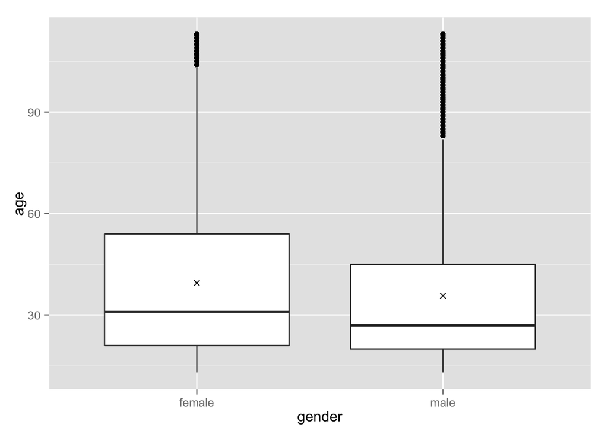

```r
library(ggplot2)
pf <- read.csv('pseudo_facebook.tsv', sep='\t')
ggplot(aes(x = gender, y = age),
       data = subset(pf, !is.na(gender))) + geom_boxplot() +
  stat_summary(fun.y = mean, geom='point', shape =4)
```

```r
library(dplyr)
pf.fc_by_age_gender <- subset(pf, !is.na(gender)) %>%
  group_by(age, gender) %>%
  summarise(mean_friend_count = mean(friend_count),
            median_friend_count = median(as.numeric(friend_count)),
            n = n()) %>%
  arrange(age) %>%
  ungroup()
```

### Plotting Conditional Summaries

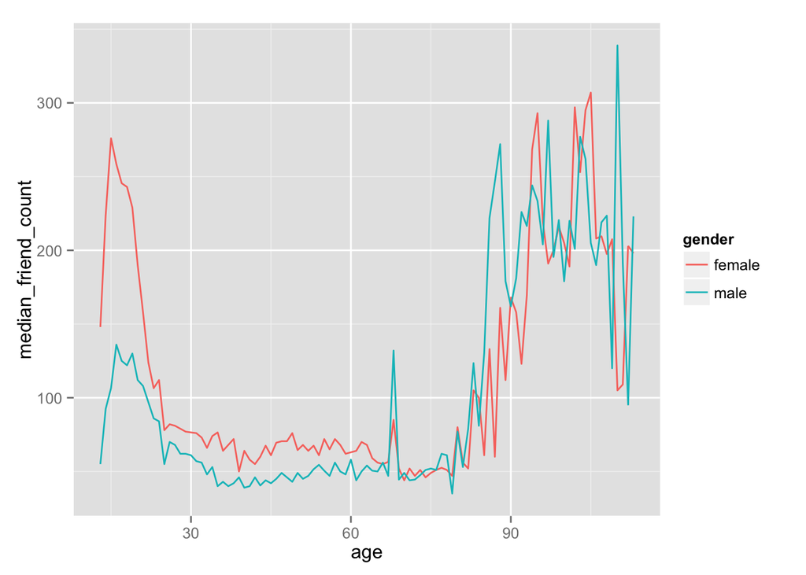

```r
ggplot(aes(age,median_friend_count,color=gender), data=pf.fc_by_age_gender) + geom_line()
```

### Ratio Plot

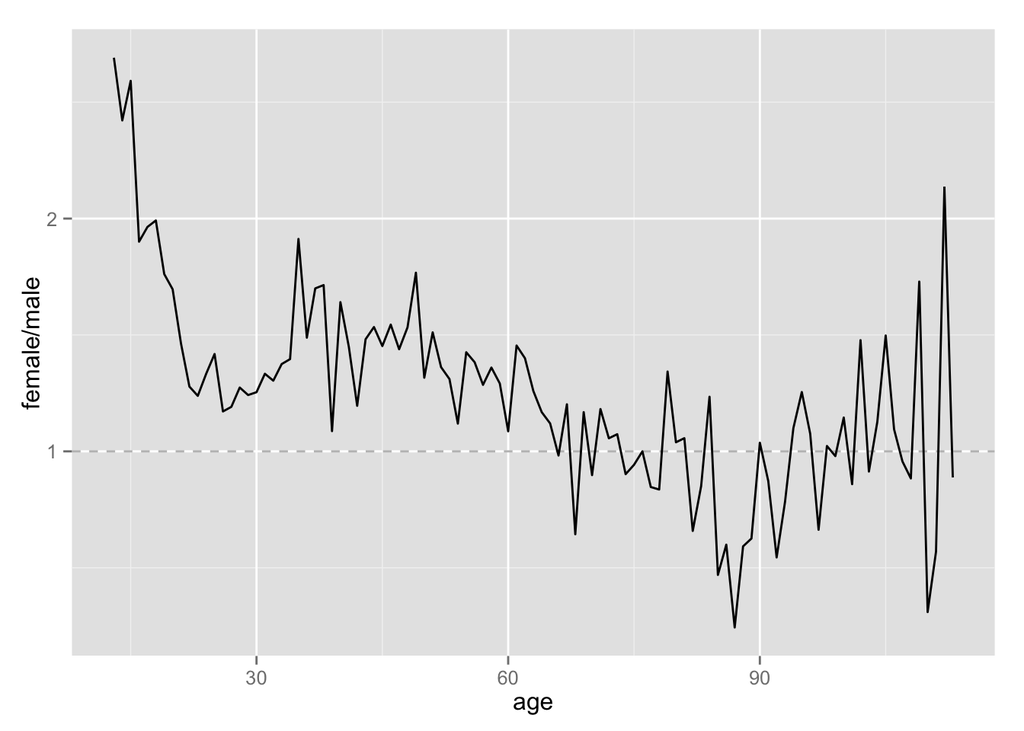

```r
#install.packages('tidyr')
#library(tidyr)
#spread(subset(pf.fc_by_age_gender, select = c('gender', 'age', 'median_friend_count')), gender, median_friend_count)

#install.packages('reshape2')
library(reshape2)
pf.fc_by_age_gender.wide <- dcast(pf.fc_by_age_gender,
                                  age ~ gender,
                                  value.var = 'median_friend_count')

ggplot(aes(age,female/male), data=pf.fc_by_age_gender.wide) + geom_line() + geom_hline(yintercept=1,linetype=2,alpha=.3)
```

### Third Quantitative Variable

Create a variable called year_joined in the pf data frame using the variable tenure and 2014 as the reference year. The variable year joined should contain the year that a user joined facebook.

```r
pf$year_joined = floor(2014 - pf$tenure/365)
```

### Cut a Variable

Create a new variable in the data frame called year_joined.bucket by using the cut function on the variable year_joined. You need to create the following buckets for the new variable, year_joined.bucket (2004, 2009] (2009, 2011] (2011, 2012] (2012, 2014] Note that a parenthesis means exclude the year and a bracket means include the year.

```r
pf$year_joined.bucket <- cut(pf$year_joined, breaks=c(2004, 2009, 2011, 2012, 2014))
```

### Plotting it All Together

Create a line graph of friend_count vs. age so that each year_joined.bucket is a line tracking the median user friend_count across age. This means you should have four different lines on your plot.

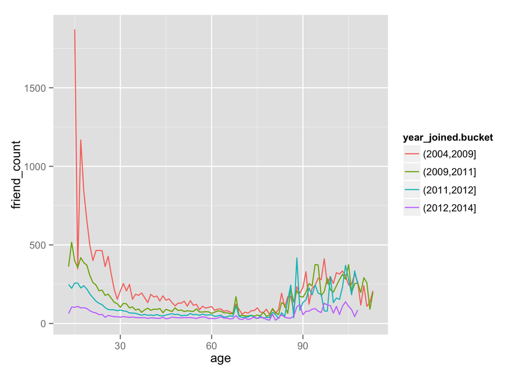

```r
ggplot(aes(age,friend_count,color=year_joined.bucket), data=subset(pf, !is.na(pf$year_joined.bucket))) + geom_line( stat = 'summary', fun.y=median)
```

### Plot the Grand Mean

1. Add another geom_line to code below to plot the grand mean of the friend count vs age.
2. Exclude any users whose year_joined.bucket is NA.
3. Use a different line type for the grand mean.

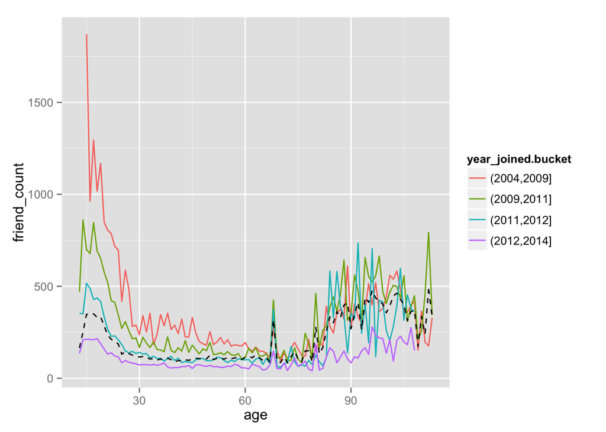

```r
ggplot(aes(age,friend_count,color=year_joined.bucket), data=subset(pf, !is.na(pf$year_joined.bucket))) + geom_line( stat = 'summary', fun.y=mean) + geom_line(linetype=2, color='black', stat='summary', fun.y=mean)
```

### Friending Rate

```r
with(subset(pf,pf$tenure >= 1), summary(friend_count/tenure))
```

```
##     Min.  1st Qu.   Median     Mean  3rd Qu.     Max.
##   0.0000   0.0775   0.2205   0.6096   0.5658 417.0000
```

### Friendships Initiated

What is the median friend rate? .2205

What is the maximum friend rate? 417

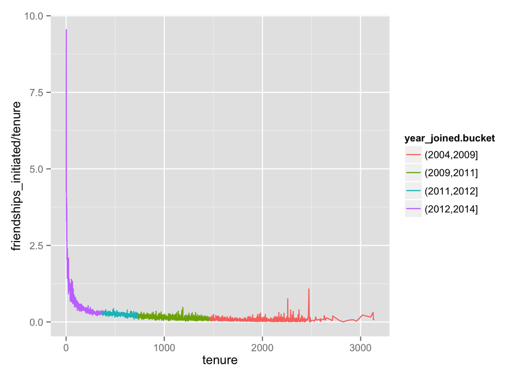

```r
ggplot(aes(tenure,friendships_initiated/tenure,color=year_joined.bucket), data=subset(pf,pf$tenure >= 1)) + geom_line(stat='summary',fun.y=mean)
```

### Bias-Variance Tradeoff Revisited

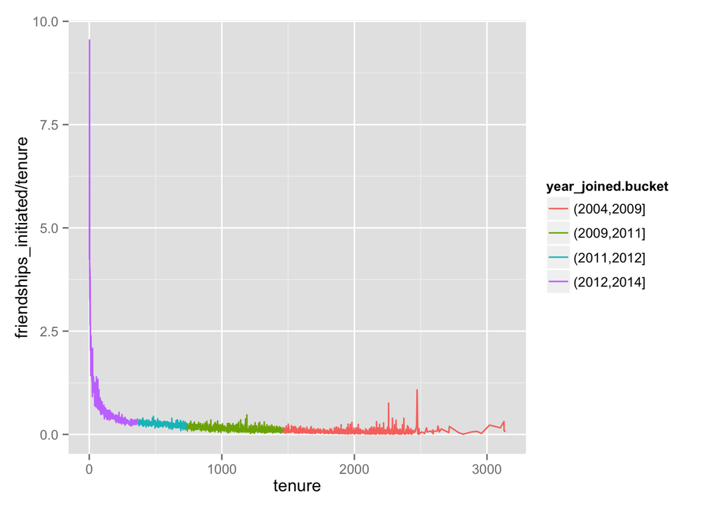

```r
ggplot(aes(x = tenure, y = friendships_initiated / tenure),
       data = subset(pf, tenure >= 1)) +
  geom_line(aes(color = year_joined.bucket),
            stat = 'summary',
            fun.y = mean)
```

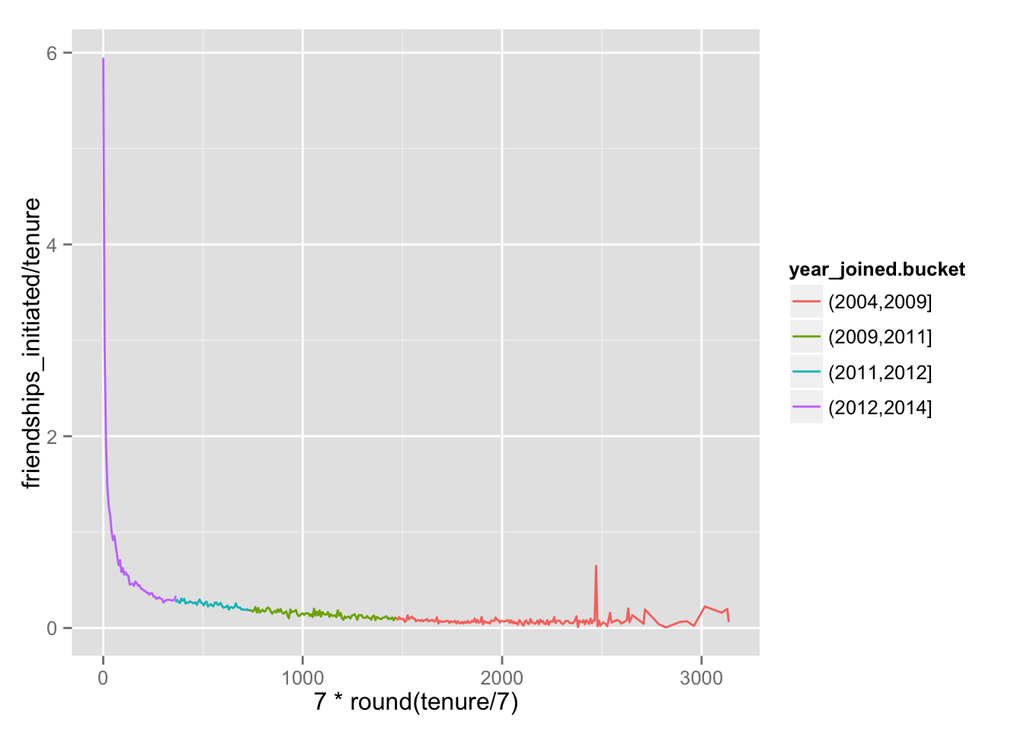

```r
ggplot(aes(x = 7 * round(tenure / 7), y = friendships_initiated / tenure),
       data = subset(pf, tenure > 0)) +
  geom_line(aes(color = year_joined.bucket),
            stat = "summary",
            fun.y = mean)
```

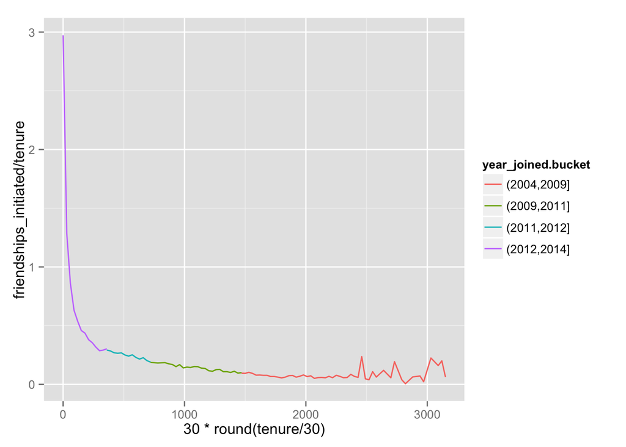

```r
ggplot(aes(x = 30 * round(tenure / 30), y = friendships_initiated / tenure),
       data = subset(pf, tenure > 0)) +
  geom_line(aes(color = year_joined.bucket),
            stat = "summary",
            fun.y = mean)
```

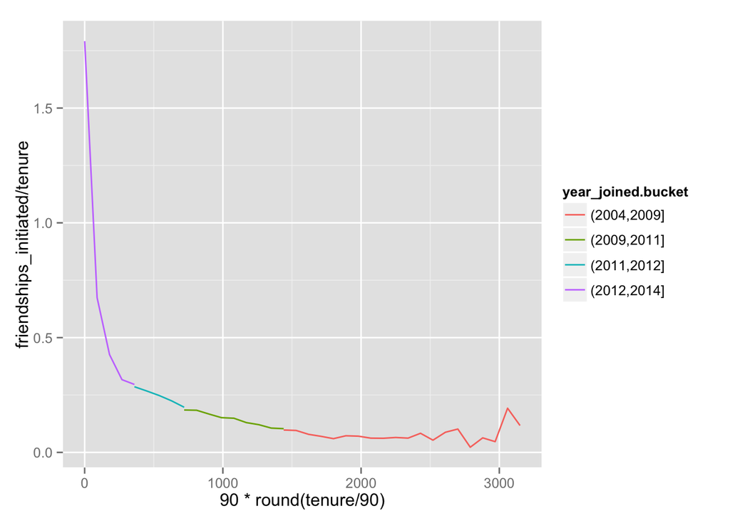

```r
ggplot(aes(x = 90 * round(tenure / 90), y = friendships_initiated / tenure),
       data = subset(pf, tenure > 0)) +
  geom_line(aes(color = year_joined.bucket),
            stat = "summary",
            fun.y = mean)
```

Instead of geom_line(), use geom_smooth() to add a smoother to the plot. You can use the defaults for geom_smooth() but do color the line by year_joined.bucket

```
## geom_smooth: method="auto" and size of largest group is >=1000, so using gam with formula: y ~ s(x, bs = "cs"). Use 'method = x' to change the smoothing method.
```

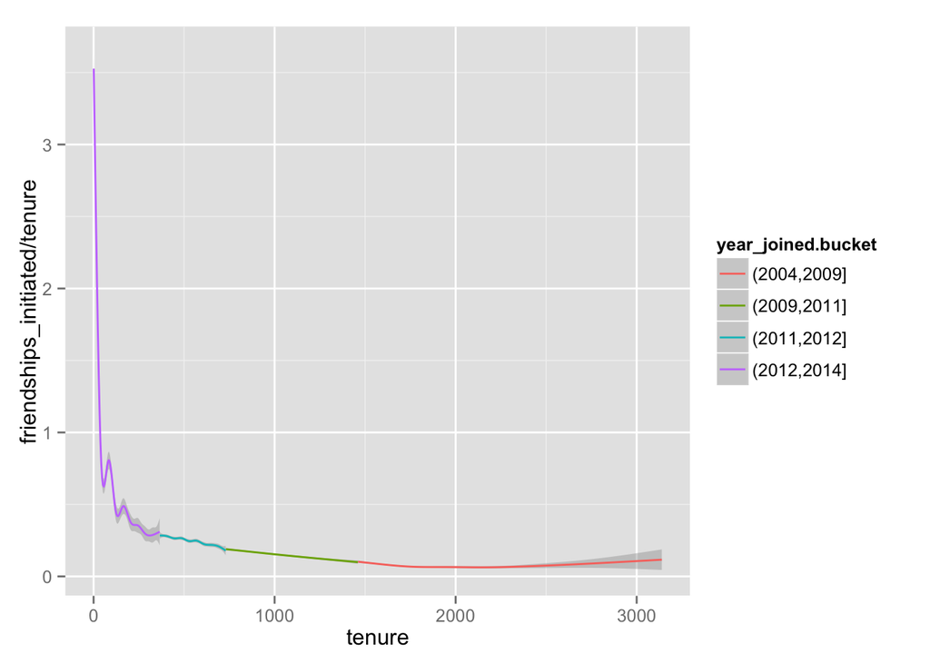

```r
ggplot(aes(x = tenure, y = friendships_initiated / tenure), data = subset(pf, tenure > 0)) + geom_smooth(aes(color = year_joined.bucket))
```

### Introducing the Yogurt Data Set

```r
yo <- read.csv('yogurt.csv')
yo$id <- factor(yo$id)
```

### Histograms Revisited

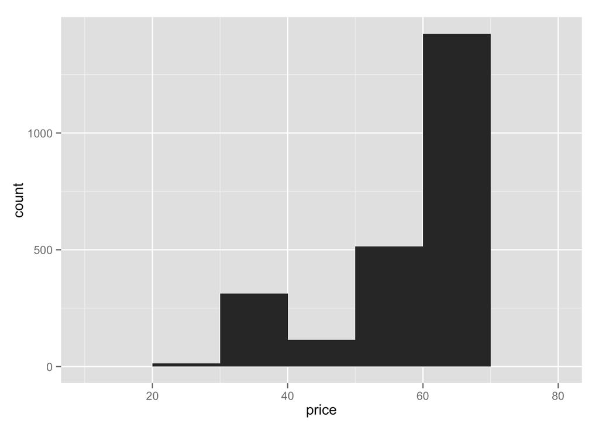

```r
qplot(price, data=yo, binwidth=10)
```

### Number of Purchases

Create a new variable called all.purchases, which gives the total counts of yogurt for each observation or household.

One way to do this is using the transform function. You can look up the function transform and run the examples of code at the bottom of the documentation to figure out what it does.

```r
yo <-transform(yo, all.purchases = strawberry + blueberry + pina.colada + plain + mixed.berry)
```

### Prices over Time

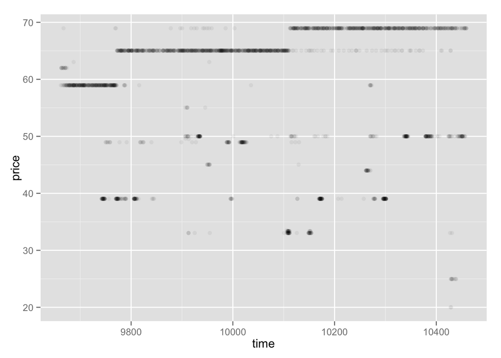

```r
ggplot(aes(time,price), data=yo) + geom_point(alpha=0.05, position = position_jitter(h=0))
```

### Looking at Samples of Households

Plot the prices paid over time for each household separately

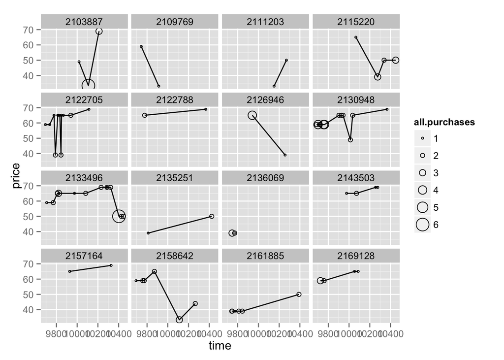

```r
set.seed(1)
#16 samples from the various ids (households) in the data
sample.ids <- sample(levels(yo$id), 16)

ggplot(aes(time,price), data = subset(yo, id %in% sample.ids)) + facet_wrap(~id) + geom_line() + geom_point(aes(size=all.purchases), pch=1)
```

### The Limits of Cross Sectional Data

### Scatterplot Matrix

```r
#install.packages('GGally')
library(GGally)
theme_set(theme_minimal(20))
set.seed(1)
pf_subset <- pf[, c(2:7)]
names(pf_subset)
```

```
## [1] "age"       "dob_day"   "dob_year"  "dob_month" "gender"    "tenure"
```

[output not shown]

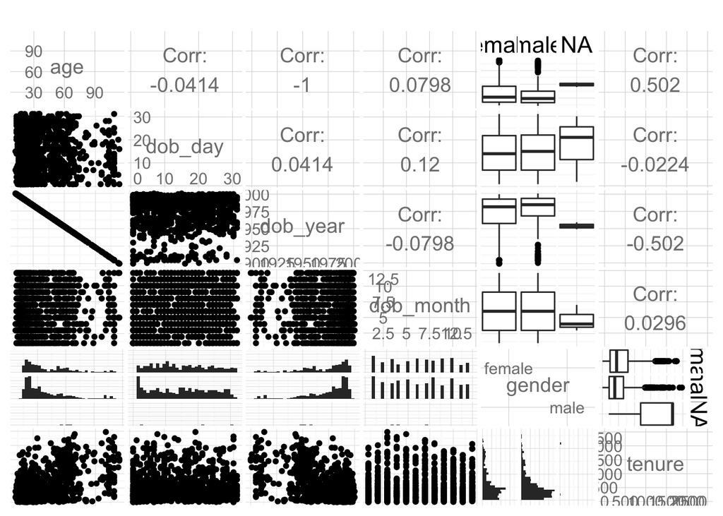

```r
ggpairs(pf_subset[sample.int(nrow(pf_subset), 1000), ], axisLabels = 'internal')
```

### Heat Maps

```r
nci <- read.table("nci.tsv")
colnames(nci) <- c(1:64)
```

```r
nci.long.samp <- melt(as.matrix(nci[1:200,]))
names(nci.long.samp) <- c("gene", "case", "value")
head(nci.long.samp)
```

```
##   gene case  value
## 1    1    1  0.300
## 2    2    1  1.180
## 3    3    1  0.550
## 4    4    1  1.140
## 5    5    1 -0.265
## 6    6    1 -0.070
```

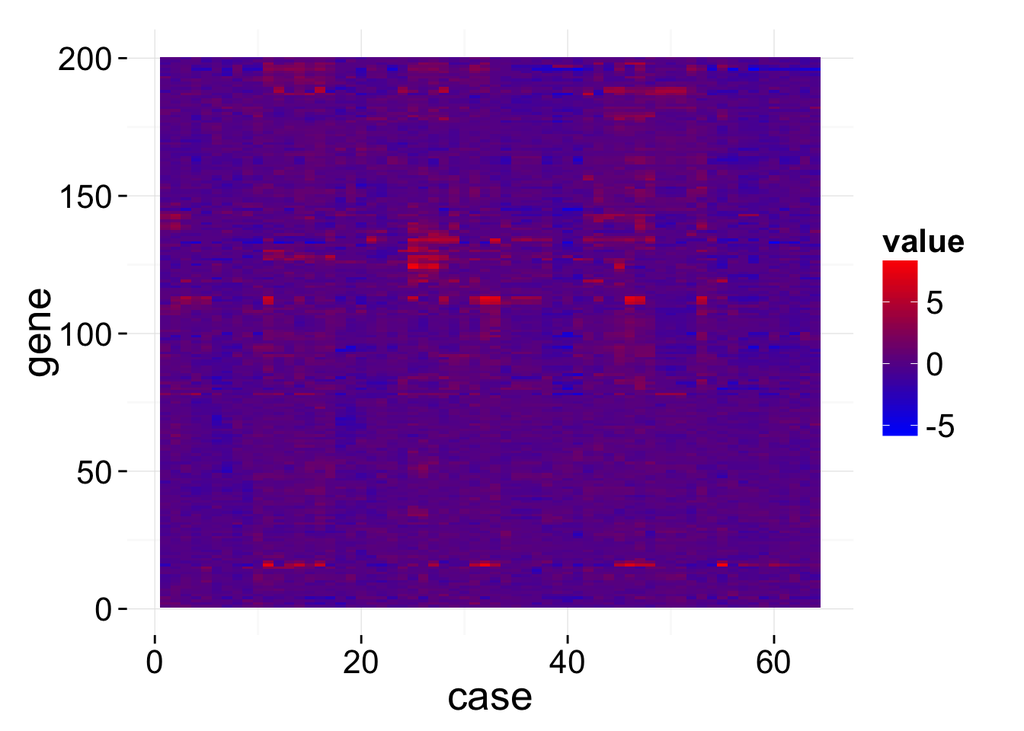

```r
ggplot(aes(y = gene, x = case, fill = value),
  data = nci.long.samp) +
  geom_tile() +
  scale_fill_gradientn(colours = colorRampPalette(c("blue", "red"))(100))
```